[figure not shown]

# Analyzing the Pokemon in Generation 7 Competitive Play

# Introduction

Pokemon, also known as Pocket Monsters, is a role playing game (RPG) series developed by Game Freak and published by Nintendo for its handheld consoles. Originally released in 1996 with Pokemon Red and Green in Japan, Pokemon became a massive gaming phenomenon with games being released for every Nintendo handheld console from the original Nintendo Gameboy to the Nintendo Switch. Since its original release, Pokemon had grown to become the highest grossing media franchise in history with a total revenue of 95 billion dollars as of present day. In Pokemon, players embark on a journey across a region full of a variety of interesting and colorful creatures where they try to catch and train as many of these creatures as possible and try to become the Pokemon League Champion. Although Pokemon is very a good single player casual experience, there is a very large online competitive community wjere people try to form the best Pokemon teams possible to win the most battles against other players.

The competive scene of Pokemon is very heavily influenced by [Smogon University](https://www.smogon.com/). Smogon University consists of the biggest competitive Pokemon community. Smogon provides guides on how to use each Pokemon effectively in competitive Pokemon battles and how to put them together in teams with other Pokemon such that each Pokemon complements each other well. The way they do this is by providing players information on the different movesets for each Pokemon, how to optimize each Pokemon based off their stats, nature and ability among other ways. The most important aspect of Smogon University is their competitive tier system. In their competitive tier system, they categorize each Pokemon by their viability in battle into the following tiers:

1. Ubers: This tier consists of legendary and very over powered Pokemon. These Pokemon are not allowed in most competitive metas due to how powerful they are. An example of a Pokemon from this tier is Mewtwo.

[figure not shown]

2. Over Used (OU): This is the premier competitive Pokemon tier. The most viable Pokemon in competitive battling are in this tier and this is the most popular metagame. An example of a Pokemon from this tier is Mega Charizard X.

[figure not shown]

3. Under Used (UU): This is the second most popular metagame. It consists of the Pokemon that are not optimal for battling in Over Used, but are too good for the bottom tiers. An example of a Pokemon from this tier is Gengar.

[figure not shown]

4. Rarely Used (RU): This is the third most popular metagame. It consists of the Pokemon that are not optimal for battling in Over Used and Under Used, but are too good for the bottom tiers. An example of a Pokemon from this tier is Venusaur.

[figure not shown]

5. Never Used (NU): This is the fourth most popular metagame. It consists of the Pokemon that are not optimal for battling in Over Used, Under Used, and Rarely Used, but are too good for worst tier. An example of a Pokemon from this tier is Blastoise.

[figure not shown]

6. PU: This is the lowest tier of competitive Pokemon battling. The name of the tier is PU not because it stands for something but to represent how bad the Pokemon are. An example of a Pokemon from this tier is Kangaskhan.

[figure not shown]

7. Untiered: There are also Pokemon that are not viable for battling in any competitive tier of Pokemon. These Pokemon will not be focused on in this tutorial.

In Pokemon, every Pokemon has 6 stats which determine how they perform in battle: Health, Attack, Defense, Special Attack, Special Defense, and Speed. Attack and Defense counteract each other, Special Attack and Special Defense counteract each other, and Speed determines which Pokemon moves first in a turn. A Pokemon with high Defense and Special Defense can be thought of as a defensive wall that can withstand many attacks, and in contrast a Pokemon with high Attack and Special Attack can be thought of as a sweeper which is able to knock out many opposing pokemon with is power. The primary focus of this tutorial will be to see how these stats come into play when determining how good a Pokemon will be on the competitive scene. The criterion for determining how good a Pokemon is competitively will be its usage in the Over Used tier.

Smogon University releases stats on the usage of each Pokemon in each competitive metagame each month [here](https://www.smogon.com/stats/). This tutorial uses the November 2nd stats for Generation 7 Over Used as that has the data for the last month of Generation 7 Over Used prior to the release of Pokemon Sword and Shield and the beginning of Generation 8.

In this tutorial, my goal is to tidy the Smogon University data given to us, learn valuable information about which stats are most important when it comes to a Pokemon's competitive viability, and predict which Pokemon will have high usage in the next generation of Pokemon. Pokemon have other attributes such as ability and moves, but the primary focus of this tutorial will be to categorize Pokemon based off of their stats. Although Pokemon is already a very popular game, not many people are familiar with the competitive Pokemon landscape. I hope this analysis of competitive Pokemon makes people interested in picking up competitive Pokemon as it is one of the most easy to join competitive game scenes via Pokemon Showdown. For Pokemon veterans like myself, I hope they will learn more about different viable Pokemon and help them build more well rounded teams.

# Data Collection and Data Processing

For the data collection and data processing part of this tutorial, I made use of Python 3 and the following libraries: [pandas](https://pandas.pydata.org/pandas-docs/stable/), [numpy](https://docs.scipy.org/doc/numpy/user/), [matplotlib](https://matplotlib.org/contents.html), [seaborn](https://seaborn.pydata.org/), and others.

```python
from re import sub
import pandas
import numpy as np
import seaborn as sns
import matplotlib.pyplot as plt
from urllib.request import urlopen
```

As stated above, in this tutorial I use data provided from Smogon university for Pokemon usage in Generation 7 Over Used for the month of October. The data is split between the different tiers of players in Pokemon Showdown. Players are ranked from an Elo of 0 to 1800 and above, where lower Elo indicates players with less skill or experience and high Elo indicates players with more skill. The data for players with an Elo ranging from 0 to 1500 can be found [here](https://www.smogon.com/stats/2019-10/gen7ou-0.txt). The data for players with an Elo ranging from 1500 to 1695 can be found [here](https://www.smogon.com/stats/2019-10/gen7ou-1500.txt). The data for players with an Elo ranging from 1695 to 1825 can be found [here](https://www.smogon.com/stats/2019-10/gen7ou-1695.txt). The data for players with an Elo above 1825 can be found [here](https://www.smogon.com/stats/2019-10/gen7ou-1825.txt).

I also used a Kaggle dataset containing the stats of each of the Pokemon I was analyzing which can be found [here](https://www.kaggle.com/rounakbanik/pokemon). This dataset did not contain stats for all of the Pokemon I had to analyze for this tutorial. Notable Pokemon in the competitive meta were missing from the dataset so I had to manually add in more than a hundred Pokemon to the dataset in Excel.

## Preprocessing the data

When I tried to pass in the text files directly into the `pandas.read_csv()` this is what happened.

```python
messy_dataframe=pandas.read_csv("gen7ou-0.txt")
messy_dataframe.head()
```

|  | Total battles: 2005100 |
| --- | --- |
| 0 | Avg. weight/team: 1.0 |
| 1 | + ---- + ------------------ + --------- + ---... |
| 2 | \| Rank \| Pokemon \| Usage % \| Raw... |
| 3 | + ---- + ------------------ + --------- + ---... |
| 4 | \| 1 \| Landorus-Therian \| 27.22006% \| 109... |

Obviously this dataframe is very messy and hard to work with so I decided to try to convert the text files into JSON. While trying to look for ways to convert the text files into JSON, I found a function made by [Ali Turfah](https://github.com/aturfah) for a [project he made analyzing Pokemon statistics](https://github.com/aturfah/smogon-usage-stats). Below is the function I used to help convert each file into JSON readable format.

```python
def parse_data(file_url):
    file_data = {}
    txt_data = urlopen(file_url).read().decode()

    data_arr = txt_data.split("\n")
    #Remove the header rows/not relevant rows
    to_delete = [0, 1]
    for i in range(len(data_arr)):
        if " + " in data_arr[i] or "| Rank" in data_arr[i]:
            to_delete.append(i)

    to_delete = list(reversed(to_delete))
    for delete_index in to_delete:
        del data_arr[delete_index]

    for row in data_arr:
        if row == "":
            continue

        datum = " " + row.strip() + " "
        datum = sub("[ ]{1,50}", " ", datum)
        datum_arr = datum.split(" | ")

        #Remove unneeded datapoints
        datum_arr = datum_arr[1:5]
        rank = datum_arr[0]
        name = datum_arr[1]
        usage_pcnt = datum_arr[2]
        usage_count = datum_arr[3]
        file_data[name] = {}
        file_data[name]["rank"] = rank
        file_data[name]["usage"] = usage_pcnt
        file_data[name]['count'] = usage_count

    return file_data
```

I used this function to convert each of the text files into JSON file, and that made it so I was able to make better pandas dataframes than before. The process of creating the JSON files was straightforward. All I did was first pass in the text file into the function then I used the output of the function and passed into a standard function that converted txt files to JSON files.

## Reading the Data

Here I am working with the data for Pokemon usage among players with an Elo between 1500 and 1695.

```python
pokemon_usage_dataframe_1500= pandas.read_json("gen7ou-1500.json")
pokemon_stats_dataframe_1500 = pandas.read_csv("Copy of pokemon.csv")
```

```python
pokemon_stats_dataframe_1500.head()
```

|  | Name | HP | Attack | Defense | Sp_Attack | Sp_Defense | Speed | Abilities | Against_Bug | Against_Dark | ... | Experience_Growth | Height_M | Japanese_Name | Percentage_Male | Pokedex_Number | Type1 | Type2 | Weight_kg | Generation | Is_Legendary |
| --- | --- | --- | --- | --- | --- | --- | --- | --- | --- | --- | --- | --- | --- | --- | --- | --- | --- | --- | --- | --- | --- |
| 0 | Bulbasaur | 45 | 49 | 49 | 65 | 65 | 45 | ['Overgrow', 'Chlorophyll'] | 1.0 | 1.0 | ... | 1059860.0 | 0.7 | Fushigidaneフシギダネ | 88.1 | 1.0 | grass | poison | 6.9 | 1.0 | 0.0 |
| 1 | Ivysaur | 60 | 62 | 63 | 80 | 80 | 60 | ['Overgrow', 'Chlorophyll'] | 1.0 | 1.0 | ... | 1059860.0 | 1.0 | Fushigisouフシギソウ | 88.1 | 2.0 | grass | poison | 13.0 | 1.0 | 0.0 |
| 2 | Venusaur | 80 | 100 | 123 | 122 | 120 | 80 | ['Overgrow', 'Chlorophyll'] | 1.0 | 1.0 | ... | 1059860.0 | 2.0 | Fushigibanaフシギバナ | 88.1 | 3.0 | grass | poison | 100.0 | 1.0 | 0.0 |
| 3 | Charmander | 39 | 52 | 43 | 60 | 50 | 65 | ['Blaze', 'Solar Power'] | 0.5 | 1.0 | ... | 1059860.0 | 0.6 | Hitokageヒトカゲ | 88.1 | 4.0 | fire | NaN | 8.5 | 1.0 | 0.0 |
| 4 | Charmeleon | 58 | 64 | 58 | 80 | 65 | 80 | ['Blaze', 'Solar Power'] | 0.5 | 1.0 | ... | 1059860.0 | 1.1 | Lizardoリザード | 88.1 | 5.0 | fire | NaN | 19.0 | 1.0 | 0.0 |

5 rows × 41 columns

In the above Pokemon stats dataset there are 41 columns. The ones that will be important to this tutorial are the following:

- Name: The name of the Pokemon
- HP: The HP stat or the Health Points of the Pokemon
- Attack: The Attack stat of the Pokemon
- Defense: The Defense stat of the Pokemon
- Sp_Attack: The Special Attack stat of the Pokemon
- Sp_Defense: The Special Defense stat of the Pokemon
- Speed: The Speed stat of the Pokemon

If you would like to learn more about how each of these stats work you can read this Bulbapedia [article](https://bulbapedia.bulbagarden.net/wiki/Statistic) explaining them.

```python
pokemon_usage_dataframe_1500.head()
```

|  | Landorus-Therian | Greninja-Ash | Tapu Koko | Ferrothorn | Heatran | Magearna | Kartana | Tapu Lele | Rotom-Wash | Zapdos | ... | Scatterbug | Gothita | Beldum | Finneon | Togedemaru-Totem | Petilil | Vanillite | Hoothoot | Skrelp | Ribombee-Totem |
| --- | --- | --- | --- | --- | --- | --- | --- | --- | --- | --- | --- | --- | --- | --- | --- | --- | --- | --- | --- | --- | --- |
| rank | 1 | 2 | 3 | 4 | 5 | 6 | 7 | 8 | 9 | 10 | ... | 890 | 891 | 892 | 893 | 894 | 895 | 896 | 897 | 898 | 899 |
| usage | 32.90168% | 17.22784% | 16.47734% | 16.20914% | 15.35089% | 15.28429% | 13.07597% | 11.45369% | 10.58506% | 10.55009% | ... | 0.00015% | 0.00014% | 0.00014% | 0.00012% | 0.00011% | 0.00010% | 0.00010% | 0.00010% | 0.00009% | 0.00006% |
| count | 1091579 | 642945 | 582109 | 616672 | 552336 | 485898 | 460699 | 377744 | 378605 | 365376 | ... | 14 | 14 | 10 | 11 | 38 | 16 | 23 | 22 | 47 | 6 |

3 rows × 899 columns

This dataframe does not look very nice. It will be easier to visualize the data if it is transposed.

```python
pokemon_usage_dataframe_1500=pokemon_usage_dataframe_1500.transpose()
pokemon_usage_dataframe_1500.head()
```

|  | rank | usage | count |
| --- | --- | --- | --- |
| Landorus-Therian | 1 | 32.90168% | 1091579 |
| Greninja-Ash | 2 | 17.22784% | 642945 |
| Tapu Koko | 3 | 16.47734% | 582109 |
| Ferrothorn | 4 | 16.20914% | 616672 |
| Heatran | 5 | 15.35089% | 552336 |

Right now the dataset is being indexed by the Pokemon name. This is not optimal so I will reset the index.

```python
pokemon_usage_dataframe_1500 = pokemon_usage_dataframe_1500.reset_index()
pokemon_usage_dataframe_1500.head()
```

|  | index | rank | usage | count |
| --- | --- | --- | --- | --- |
| 0 | Landorus-Therian | 1 | 32.90168% | 1091579 |
| 1 | Greninja-Ash | 2 | 17.22784% | 642945 |
| 2 | Tapu Koko | 3 | 16.47734% | 582109 |
| 3 | Ferrothorn | 4 | 16.20914% | 616672 |
| 4 | Heatran | 5 | 15.35089% | 552336 |

I will now rename the columns in the dataset to give them better or more formal names and make them easier to work with.

```python
pokemon_usage_dataframe_1500=pokemon_usage_dataframe_1500.rename(columns={"index":"Pokemon", "rank":"Rank", "usage":"Usage", "count":"Count"})
pokemon_usage_dataframe_1500.head()
```

|  | Pokemon | Rank | Usage | Count |
| --- | --- | --- | --- | --- |
| 0 | Landorus-Therian | 1 | 32.90168% | 1091579 |
| 1 | Greninja-Ash | 2 | 17.22784% | 642945 |
| 2 | Tapu Koko | 3 | 16.47734% | 582109 |
| 3 | Ferrothorn | 4 | 16.20914% | 616672 |
| 4 | Heatran | 5 | 15.35089% | 552336 |

This is much better. In the Pokemon usage dataset, the columns are as follows

- Pokemon: This is the name of the Pokemon
- Rank: This is the rank of the Pokemon based off of usage. Pokemon with lower rank are used more than those with higher rank
- Usage: This is the percentage of usage of the Pokemon out of all of the Pokemon.
- Count: This is the total usage of the Pokemon

If you are curious as to how each Pokemon looks like and more about their attributes, just Google the Pokemon name and it should be the first thing that pops up.

## Tidying the Data

The prime focus of this tutorial to see the affect of a Pokemon's stat distribution on its usage in competitive battles. I will merge the Pokemon Stats dataset and the Pokemon Usage dataset. I will only take the columns for the stats of the Pokemon from the Pokemon Stats dataset and ignore the other columns like ability and type weaknesses.

First I create temporary collumns filled with NP.nan elements in the Pokemon usage dataframe.

```python
placeholder=np.full(899, np.nan)
pokemon_usage_dataframe_1500["HP"]=placeholder
pokemon_usage_dataframe_1500["Attack"]=placeholder
pokemon_usage_dataframe_1500["Defense"]=placeholder
pokemon_usage_dataframe_1500["Special Attack"]=placeholder
pokemon_usage_dataframe_1500["Special Defense"]=placeholder
pokemon_usage_dataframe_1500["Speed"]=placeholder
pokemon_usage_dataframe_1500.head()
```

|  | Pokemon | Rank | Usage | Count | HP | Attack | Defense | Special Attack | Special Defense | Speed |
| --- | --- | --- | --- | --- | --- | --- | --- | --- | --- | --- |
| 0 | Landorus-Therian | 1 | 32.90168% | 1091579 | NaN | NaN | NaN | NaN | NaN | NaN |
| 1 | Greninja-Ash | 2 | 17.22784% | 642945 | NaN | NaN | NaN | NaN | NaN | NaN |
| 2 | Tapu Koko | 3 | 16.47734% | 582109 | NaN | NaN | NaN | NaN | NaN | NaN |
| 3 | Ferrothorn | 4 | 16.20914% | 616672 | NaN | NaN | NaN | NaN | NaN | NaN |
| 4 | Heatran | 5 | 15.35089% | 552336 | NaN | NaN | NaN | NaN | NaN | NaN |

Next I will copy the values for each Pokemon's stats by iterating through the Pokemon Stats dataframe and put them into the columns I created.

```python
index = 0
for first_row in pokemon_usage_dataframe_1500.iterrows():
    for second_row in pokemon_stats_dataframe_1500.iterrows():
        if first_row[1]["Pokemon"]==second_row[1]["Name"]:
            pokemon_usage_dataframe_1500["HP"][index] = second_row[1]["HP"]
            pokemon_usage_dataframe_1500["Attack"][index] = second_row[1]["Attack"]
            pokemon_usage_dataframe_1500["Defense"][index] = second_row[1]["Defense"]
            pokemon_usage_dataframe_1500["Special Attack"][index] = second_row[1]["Sp_Attack"]
            pokemon_usage_dataframe_1500["Special Defense"][index] = second_row[1]["Sp_Defense"]
            pokemon_usage_dataframe_1500["Speed"][index] = second_row[1]["Speed"]
    index=index+1
```

```python
pokemon_usage_dataframe_1500.head()
```

|  | Pokemon | Rank | Usage | Count | HP | Attack | Defense | Special Attack | Special Defense | Speed |
| --- | --- | --- | --- | --- | --- | --- | --- | --- | --- | --- |
| 0 | Landorus-Therian | 1 | 32.90168% | 1091579 | 89.0 | 145.0 | 90.0 | 105.0 | 80.0 | 91.0 |
| 1 | Greninja-Ash | 2 | 17.22784% | 642945 | 72.0 | 145.0 | 67.0 | 153.0 | 71.0 | 132.0 |
| 2 | Tapu Koko | 3 | 16.47734% | 582109 | 70.0 | 115.0 | 85.0 | 95.0 | 75.0 | 130.0 |
| 3 | Ferrothorn | 4 | 16.20914% | 616672 | 74.0 | 94.0 | 131.0 | 54.0 | 116.0 | 20.0 |
| 4 | Heatran | 5 | 15.35089% | 552336 | 91.0 | 90.0 | 106.0 | 130.0 | 106.0 | 77.0 |

Now I will strip the percentage from the Usage and convert the values in the Usage column into floating point values. This will make it much more easier to use the Usage column when I am performining analysis on this data.

```python
for i in range(0,899):
    pokemon_usage_dataframe_1500["Usage"][i]=float(pokemon_usage_dataframe_1500["Usage"][i].strip('%'))/100
```

```python
pokemon_usage_dataframe_1500.head()
```

|  | Pokemon | Rank | Usage | Count | HP | Attack | Defense | Special Attack | Special Defense | Speed |
| --- | --- | --- | --- | --- | --- | --- | --- | --- | --- | --- |
| 0 | Landorus-Therian | 1 | 0.329017 | 1091579 | 89.0 | 145.0 | 90.0 | 105.0 | 80.0 | 91.0 |
| 1 | Greninja-Ash | 2 | 0.172278 | 642945 | 72.0 | 145.0 | 67.0 | 153.0 | 71.0 | 132.0 |
| 2 | Tapu Koko | 3 | 0.164773 | 582109 | 70.0 | 115.0 | 85.0 | 95.0 | 75.0 | 130.0 |
| 3 | Ferrothorn | 4 | 0.162091 | 616672 | 74.0 | 94.0 | 131.0 | 54.0 | 116.0 | 20.0 |
| 4 | Heatran | 5 | 0.153509 | 552336 | 91.0 | 90.0 | 106.0 | 130.0 | 106.0 | 77.0 |

Perhaps it may be the case that when performing analysis on usage vs stats that there is no clear relationship. For that reason I will create columns based off of the following combinations of stats: Attack + Speed, Special Attack + Speed, Attack + Special Attack, Defense + Special Defense, and the stat total. The reason why these permutations were chosen is that the Attack and Speed stat complement each other well, Special Attack and Speed complement each other well, and Defense and Special Defense complement each other well.

```python
pokemon_usage_dataframe_1500["Attack + Speed"]=placeholder
pokemon_usage_dataframe_1500["Special Attack + Speed"]=placeholder
pokemon_usage_dataframe_1500["Attack + Special Attack"]=placeholder
pokemon_usage_dataframe_1500["Defense + Special Defense"]=placeholder
pokemon_usage_dataframe_1500["Total"]=placeholder
index = 0
for first_row in pokemon_usage_dataframe_1500.iterrows():
    for second_row in pokemon_stats_dataframe_1500.iterrows():
        if first_row[1]["Pokemon"]==second_row[1]["Name"]:
            pokemon_usage_dataframe_1500["Attack + Speed"][index]=second_row[1]["Attack"]+second_row[1]["Speed"]
            pokemon_usage_dataframe_1500["Special Attack + Speed"][index]=second_row[1]["Sp_Attack"]+second_row[1]["Speed"]
            pokemon_usage_dataframe_1500["Attack + Special Attack"][index]=second_row[1]["Sp_Attack"]+second_row[1]["Attack"]
            pokemon_usage_dataframe_1500["Defense + Special Defense"][index]=second_row[1]["Sp_Defense"]+second_row[1]["Defense"]
            pokemon_usage_dataframe_1500["Total"][index] = second_row[1]["Sp_Defense"]+second_row[1]["Defense"]+second_row[1]["Sp_Attack"]+second_row[1]["Attack"]+second_row[1]["HP"]+second_row[1]["Speed"]
    index=index+1
```

```python
pokemon_usage_dataframe_1500.head()
```

|  | Pokemon | Rank | Usage | Count | HP | Attack | Defense | Special Attack | Special Defense | Speed | Attack + Speed | Special Attack + Speed | Attack + Special Attack | Defense + Special Defense | Total |
| --- | --- | --- | --- | --- | --- | --- | --- | --- | --- | --- | --- | --- | --- | --- | --- |
| 0 | Landorus-Therian | 1 | 0.329017 | 1091579 | 89.0 | 145.0 | 90.0 | 105.0 | 80.0 | 91.0 | 236.0 | 196.0 | 250.0 | 170.0 | 600.0 |
| 1 | Greninja-Ash | 2 | 0.172278 | 642945 | 72.0 | 145.0 | 67.0 | 153.0 | 71.0 | 132.0 | 277.0 | 285.0 | 298.0 | 138.0 | 640.0 |
| 2 | Tapu Koko | 3 | 0.164773 | 582109 | 70.0 | 115.0 | 85.0 | 95.0 | 75.0 | 130.0 | 245.0 | 225.0 | 210.0 | 160.0 | 570.0 |
| 3 | Ferrothorn | 4 | 0.162091 | 616672 | 74.0 | 94.0 | 131.0 | 54.0 | 116.0 | 20.0 | 114.0 | 74.0 | 148.0 | 247.0 | 489.0 |
| 4 | Heatran | 5 | 0.153509 | 552336 | 91.0 | 90.0 | 106.0 | 130.0 | 106.0 | 77.0 | 167.0 | 207.0 | 220.0 | 212.0 | 600.0 |

Great! Now the data for the Pokemon used among players with Elo between 1500 and 1695 is in a form that is good to perform analysis on. Now we have to repeat all the steps I described above for the other tiers of competitive play.

Here is the cleaning process for the Pokemon usage stats among players with Elo between 0 and 1500:

```python
pokemon_usage_dataframe_0= pandas.read_json("gen7ou-0.json")
pokemon_stats_dataframe_0 = pandas.read_csv("Copy of pokemon.csv")
pokemon_usage_dataframe_0=pokemon_usage_dataframe_0.transpose()

pokemon_usage_dataframe_0 = pokemon_usage_dataframe_0.reset_index()
pokemon_usage_dataframe_0=pokemon_usage_dataframe_0.rename(columns={"index":"Pokemon", "rank":"Rank", "usage":"Usage", "count":"Count"})
placeholder=np.full(899, np.nan)

pokemon_usage_dataframe_0["HP"]=placeholder
pokemon_usage_dataframe_0["Attack"]=placeholder
pokemon_usage_dataframe_0["Defense"]=placeholder
pokemon_usage_dataframe_0["Special Attack"]=placeholder
pokemon_usage_dataframe_0["Special Defense"]=placeholder
pokemon_usage_dataframe_0["Speed"]=placeholder

index = 0
for first_row in pokemon_usage_dataframe_0.iterrows():
    for second_row in pokemon_stats_dataframe_0.iterrows():
        if first_row[1]["Pokemon"]==second_row[1]["Name"]:
            pokemon_usage_dataframe_0["HP"][index] = second_row[1]["HP"]
            pokemon_usage_dataframe_0["Attack"][index] = second_row[1]["Attack"]
            pokemon_usage_dataframe_0["Defense"][index] = second_row[1]["Defense"]
            pokemon_usage_dataframe_0["Special Attack"][index] = second_row[1]["Sp_Attack"]
            pokemon_usage_dataframe_0["Special Defense"][index] = second_row[1]["Sp_Defense"]
            pokemon_usage_dataframe_0["Speed"][index] = second_row[1]["Speed"]
    index=index+1

for i in range(0,899):
    pokemon_usage_dataframe_0["Usage"][i]=float(pokemon_usage_dataframe_0["Usage"][i].strip('%'))/100

pokemon_usage_dataframe_0["Attack + Speed"]=placeholder
pokemon_usage_dataframe_0["Special Attack + Speed"]=placeholder
pokemon_usage_dataframe_0["Attack + Special Attack"]=placeholder
pokemon_usage_dataframe_0["Defense + Special Defense"]=placeholder
pokemon_usage_dataframe_0["Total"]=placeholder
index = 0
for first_row in pokemon_usage_dataframe_0.iterrows():
    for second_row in pokemon_stats_dataframe_0.iterrows():
        if first_row[1]["Pokemon"]==second_row[1]["Name"]:
            pokemon_usage_dataframe_0["Attack + Speed"][index]=second_row[1]["Attack"]+second_row[1]["Speed"]
            pokemon_usage_dataframe_0["Special Attack + Speed"][index]=second_row[1]["Sp_Attack"]+second_row[1]["Speed"]
            pokemon_usage_dataframe_0["Attack + Special Attack"][index]=second_row[1]["Sp_Attack"]+second_row[1]["Attack"]
            pokemon_usage_dataframe_0["Defense + Special Defense"][index]=second_row[1]["Sp_Defense"]+second_row[1]["Defense"]
            pokemon_usage_dataframe_0["Total"][index] = second_row[1]["Sp_Defense"]+second_row[1]["Defense"]+second_row[1]["Sp_Attack"]+second_row[1]["Attack"]+second_row[1]["HP"]+second_row[1]["Speed"]
    index=index+1
```

[output not shown]

```python
pokemon_usage_dataframe_0.head()
```

|  | Pokemon | Rank | Usage | Count | HP | Attack | Defense | Special Attack | Special Defense | Speed | Attack + Speed | Special Attack + Speed | Attack + Special Attack | Defense + Special Defense | Total |
| --- | --- | --- | --- | --- | --- | --- | --- | --- | --- | --- | --- | --- | --- | --- | --- |
| 0 | Landorus-Therian | 1 | 0.272201 | 1091579 | 89.0 | 145.0 | 90.0 | 105.0 | 80.0 | 91.0 | 236.0 | 196.0 | 250.0 | 170.0 | 600.0 |
| 1 | Greninja-Ash | 2 | 0.160327 | 642945 | 72.0 | 145.0 | 67.0 | 153.0 | 71.0 | 132.0 | 277.0 | 285.0 | 298.0 | 138.0 | 640.0 |
| 2 | Ferrothorn | 3 | 0.153776 | 616672 | 74.0 | 94.0 | 131.0 | 54.0 | 116.0 | 20.0 | 114.0 | 74.0 | 148.0 | 247.0 | 489.0 |
| 3 | Tapu Koko | 4 | 0.145157 | 582109 | 70.0 | 115.0 | 85.0 | 95.0 | 75.0 | 130.0 | 245.0 | 225.0 | 210.0 | 160.0 | 570.0 |
| 4 | Heatran | 5 | 0.137733 | 552336 | 91.0 | 90.0 | 106.0 | 130.0 | 106.0 | 77.0 | 167.0 | 207.0 | 220.0 | 212.0 | 600.0 |

Here is the cleaning process for the Pokemon usage stats among players with Elo between 1695 and 1825:

```python
pokemon_usage_dataframe_1695= pandas.read_json("gen7ou-1695.json")
pokemon_stats_dataframe_1695 = pandas.read_csv("Copy of pokemon.csv")
pokemon_usage_dataframe_1695=pokemon_usage_dataframe_1695.transpose()

pokemon_usage_dataframe_1695 = pokemon_usage_dataframe_1695.reset_index()
pokemon_usage_dataframe_1695=pokemon_usage_dataframe_1695.rename(columns={"index":"Pokemon", "rank":"Rank", "usage":"Usage", "count":"Count"})
placeholder=np.full(899, np.nan)

pokemon_usage_dataframe_1695["HP"]=placeholder
pokemon_usage_dataframe_1695["Attack"]=placeholder
pokemon_usage_dataframe_1695["Defense"]=placeholder
pokemon_usage_dataframe_1695["Special Attack"]=placeholder
pokemon_usage_dataframe_1695["Special Defense"]=placeholder
pokemon_usage_dataframe_1695["Speed"]=placeholder

index = 0
for first_row in pokemon_usage_dataframe_1695.iterrows():
    for second_row in pokemon_stats_dataframe_1695.iterrows():
        if first_row[1]["Pokemon"]==second_row[1]["Name"]:
            pokemon_usage_dataframe_1695["HP"][index] = second_row[1]["HP"]
            pokemon_usage_dataframe_1695["Attack"][index] = second_row[1]["Attack"]
            pokemon_usage_dataframe_1695["Defense"][index] = second_row[1]["Defense"]
            pokemon_usage_dataframe_1695["Special Attack"][index] = second_row[1]["Sp_Attack"]
            pokemon_usage_dataframe_1695["Special Defense"][index] = second_row[1]["Sp_Defense"]
            pokemon_usage_dataframe_1695["Speed"][index] = second_row[1]["Speed"]
    index=index+1

for i in range(0,899):
    pokemon_usage_dataframe_1695["Usage"][i]=float(pokemon_usage_dataframe_1695["Usage"][i].strip('%'))/100

pokemon_usage_dataframe_1695["Attack + Speed"]=placeholder
pokemon_usage_dataframe_1695["Special Attack + Speed"]=placeholder
pokemon_usage_dataframe_1695["Attack + Special Attack"]=placeholder
pokemon_usage_dataframe_1695["Defense + Special Defense"]=placeholder
pokemon_usage_dataframe_1695["Total"]=placeholder
index = 0
for first_row in pokemon_usage_dataframe_1695.iterrows():
    for second_row in pokemon_stats_dataframe_1695.iterrows():
        if first_row[1]["Pokemon"]==second_row[1]["Name"]:
            pokemon_usage_dataframe_1695["Attack + Speed"][index]=second_row[1]["Attack"]+second_row[1]["Speed"]
            pokemon_usage_dataframe_1695["Special Attack + Speed"][index]=second_row[1]["Sp_Attack"]+second_row[1]["Speed"]
            pokemon_usage_dataframe_1695["Attack + Special Attack"][index]=second_row[1]["Sp_Attack"]+second_row[1]["Attack"]
            pokemon_usage_dataframe_1695["Defense + Special Defense"][index]=second_row[1]["Sp_Defense"]+second_row[1]["Defense"]
            pokemon_usage_dataframe_1695["Total"][index] = second_row[1]["Sp_Defense"]+second_row[1]["Defense"]+second_row[1]["Sp_Attack"]+second_row[1]["Attack"]+second_row[1]["HP"]+second_row[1]["Speed"]
    index=index+1
```

[output not shown]

```python
pokemon_usage_dataframe_1695.head()
```

|  | Pokemon | Rank | Usage | Count | HP | Attack | Defense | Special Attack | Special Defense | Speed | Attack + Speed | Special Attack + Speed | Attack + Special Attack | Defense + Special Defense | Total |
| --- | --- | --- | --- | --- | --- | --- | --- | --- | --- | --- | --- | --- | --- | --- | --- |
| 0 | Landorus-Therian | 1 | 0.416943 | 1091579 | 89.0 | 145.0 | 90.0 | 105.0 | 80.0 | 91.0 | 236.0 | 196.0 | 250.0 | 170.0 | 600.0 |
| 1 | Magearna | 2 | 0.235405 | 485898 | 80.0 | 95.0 | 115.0 | 130.0 | 115.0 | 65.0 | 160.0 | 195.0 | 225.0 | 230.0 | 600.0 |
| 2 | Greninja-Ash | 3 | 0.175683 | 642945 | 72.0 | 145.0 | 67.0 | 153.0 | 71.0 | 132.0 | 277.0 | 285.0 | 298.0 | 138.0 | 640.0 |
| 3 | Tapu Koko | 4 | 0.16836 | 582109 | 70.0 | 115.0 | 85.0 | 95.0 | 75.0 | 130.0 | 245.0 | 225.0 | 210.0 | 160.0 | 570.0 |
| 4 | Ferrothorn | 5 | 0.165765 | 616672 | 74.0 | 94.0 | 131.0 | 54.0 | 116.0 | 20.0 | 114.0 | 74.0 | 148.0 | 247.0 | 489.0 |

Here is the cleaning process for the Pokemon usage stats among players with Elo above 1825:

```python
pokemon_usage_dataframe_1825= pandas.read_json("gen7ou-1825.json")
pokemon_stats_dataframe_1825 = pandas.read_csv("Copy of pokemon.csv")
pokemon_usage_dataframe_1825=pokemon_usage_dataframe_1825.transpose()

pokemon_usage_dataframe_1825 = pokemon_usage_dataframe_1825.reset_index()
pokemon_usage_dataframe_1825=pokemon_usage_dataframe_1825.rename(columns={"index":"Pokemon", "rank":"Rank", "usage":"Usage", "count":"Count"})
placeholder=np.full(899, np.nan)

pokemon_usage_dataframe_1825["HP"]=placeholder
pokemon_usage_dataframe_1825["Attack"]=placeholder
pokemon_usage_dataframe_1825["Defense"]=placeholder
pokemon_usage_dataframe_1825["Special Attack"]=placeholder
pokemon_usage_dataframe_1825["Special Defense"]=placeholder
pokemon_usage_dataframe_1825["Speed"]=placeholder

index = 0
for first_row in pokemon_usage_dataframe_1825.iterrows():
    for second_row in pokemon_stats_dataframe_1825.iterrows():
        if first_row[1]["Pokemon"]==second_row[1]["Name"]:
            pokemon_usage_dataframe_1825["HP"][index] = second_row[1]["HP"]
            pokemon_usage_dataframe_1825["Attack"][index] = second_row[1]["Attack"]
            pokemon_usage_dataframe_1825["Defense"][index] = second_row[1]["Defense"]
            pokemon_usage_dataframe_1825["Special Attack"][index] = second_row[1]["Sp_Attack"]
            pokemon_usage_dataframe_1825["Special Defense"][index] = second_row[1]["Sp_Defense"]
            pokemon_usage_dataframe_1825["Speed"][index] = second_row[1]["Speed"]
    index=index+1

for i in range(0,899):
    pokemon_usage_dataframe_1825["Usage"][i]=float(pokemon_usage_dataframe_1825["Usage"][i].strip('%'))/100

pokemon_usage_dataframe_1825["Attack + Speed"]=placeholder
pokemon_usage_dataframe_1825["Special Attack + Speed"]=placeholder
pokemon_usage_dataframe_1825["Attack + Special Attack"]=placeholder
pokemon_usage_dataframe_1825["Defense + Special Defense"]=placeholder
pokemon_usage_dataframe_1825["Total"]=placeholder
index = 0
for first_row in pokemon_usage_dataframe_1825.iterrows():
    for second_row in pokemon_stats_dataframe_1825.iterrows():
        if first_row[1]["Pokemon"]==second_row[1]["Name"]:
            pokemon_usage_dataframe_1825["Attack + Speed"][index]=second_row[1]["Attack"]+second_row[1]["Speed"]
            pokemon_usage_dataframe_1825["Special Attack + Speed"][index]=second_row[1]["Sp_Attack"]+second_row[1]["Speed"]
            pokemon_usage_dataframe_1825["Attack + Special Attack"][index]=second_row[1]["Sp_Attack"]+second_row[1]["Attack"]
            pokemon_usage_dataframe_1825["Defense + Special Defense"][index]=second_row[1]["Sp_Defense"]+second_row[1]["Defense"]
            pokemon_usage_dataframe_1825["Total"][index] = second_row[1]["Sp_Defense"]+second_row[1]["Defense"]+second_row[1]["Sp_Attack"]+second_row[1]["Attack"]+second_row[1]["HP"]+second_row[1]["Speed"]
    index=index+1
```

[output not shown]

```python
pokemon_usage_dataframe_1825.head()
```

|  | Pokemon | Rank | Usage | Count | HP | Attack | Defense | Special Attack | Special Defense | Speed | Attack + Speed | Special Attack + Speed | Attack + Special Attack | Defense + Special Defense | Total |
| --- | --- | --- | --- | --- | --- | --- | --- | --- | --- | --- | --- | --- | --- | --- | --- |
| 0 | Landorus-Therian | 1 | 0.397264 | 1091579 | 89.0 | 145.0 | 90.0 | 105.0 | 80.0 | 91.0 | 236.0 | 196.0 | 250.0 | 170.0 | 600.0 |
| 1 | Magearna | 2 | 0.246369 | 485898 | 80.0 | 95.0 | 115.0 | 130.0 | 115.0 | 65.0 | 160.0 | 195.0 | 225.0 | 230.0 | 600.0 |
| 2 | Ferrothorn | 3 | 0.187996 | 616672 | 74.0 | 94.0 | 131.0 | 54.0 | 116.0 | 20.0 | 114.0 | 74.0 | 148.0 | 247.0 | 489.0 |
| 3 | Tornadus-Therian | 4 | 0.183254 | 322630 | 79.0 | 100.0 | 80.0 | 110.0 | 90.0 | 121.0 | 221.0 | 231.0 | 210.0 | 170.0 | 580.0 |
| 4 | Heatran | 5 | 0.178237 | 552336 | 91.0 | 90.0 | 106.0 | 130.0 | 106.0 | 77.0 | 167.0 | 207.0 | 220.0 | 212.0 | 600.0 |

# Exploratory Data Analysis

### Pie Chart

Let's start off by creating pie charts forthe highest tier of Pokemon usage so it will be easy to visualize how much each Pokemon is used in the most competitive play. I did not make pie charts for every tier due to how much space this pie chart takes due to the amount of Pokemon that exist. To make the pie chart, I make use of matplotlib.

```python
x = pokemon_usage_dataframe_1825["Pokemon"]
y = pokemon_usage_dataframe_1825["Usage"]
#colors = ['yellowgreen','red','gold','lightskyblue','white','lightcoral','blue','pink', 'darkgreen','yellow','grey','violet','magenta','cyan']
porcent = 100.*y/y.sum()

patches, texts = plt.pie(y, startangle=90, radius=1.2)
labels = ['{0} - {1:1.2f} %'.format(i,j) for i,j in zip(x, porcent)]

sort_legend = True
if sort_legend:
    patches, labels, dummy =  zip(*sorted(zip(patches, labels, y),
                                          key=lambda x: x[2],
                                          reverse=True))

plt.legend(patches, labels, loc='left center', bbox_to_anchor=(-0.1, 1.),
           fontsize=8)

plt.savefig('piechart.png', bbox_inches='tight')
```

[figure not shown]

From the pie chart is quite clear that Landorus-Therian is clearly a very used Pokemon, followed by Magearna and Ferrothorn.

#### Attack vs Usage

Now let's generate scatter plots based off of Attack vs Usage for each tier of competitive Pokemon. In order to generate the scatter plots, I made use of Seaborn's `scatterplot()` function.

Here is Attack vs Usage for players with an Elo between 0 and 1500.

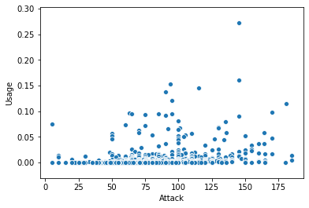

```python
ax1= sns.scatterplot(x= "Attack", y="Usage", data=pokemon_usage_dataframe_0)
```

Here is Attack vs Usage for players with an Elo between 1500 and 1695.

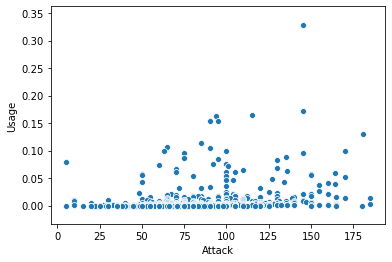

```python
ax1= sns.scatterplot(x= "Attack", y="Usage", data=pokemon_usage_dataframe_1500)
```

Here is Attack vs Usage for players with an Elo between 1695 and 1825.

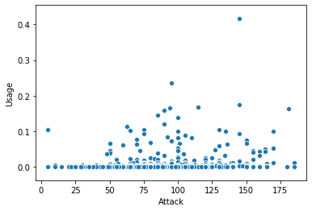

```python
ax1= sns.scatterplot(x= "Attack", y="Usage", data=pokemon_usage_dataframe_1695)
```

Here is Attack vs Usage for players with an Elo above 1825.

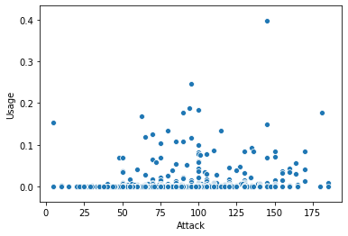

```python
ax1= sns.scatterplot(x= "Attack", y="Usage", data=pokemon_usage_dataframe_1825)
```

From these scatter plots it can be seen that more Pokemon generally used if they have an attack stat at or above 100. The trend isn't as clear as I would have liked, but it is somewhat linear.

#### Defense vs Usage

Now let's generate scatter plots based off of Defense vs Usage for each tier of competitive Pokemon.

Here is Defense vs Usage for players with an Elo between 0 and 1500.

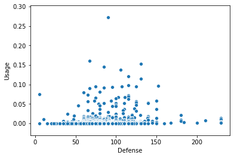

```python
ax1= sns.scatterplot(x= "Defense", y="Usage", data=pokemon_usage_dataframe_0)
```

Here is Defense vs Usage for players with an Elo between 1500 and 1695.

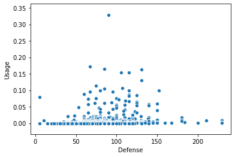

```python
ax1= sns.scatterplot(x= "Defense", y="Usage", data=pokemon_usage_dataframe_1500)
```

Here is Defense vs Usage for players with an Elo between 1695 and 1825.

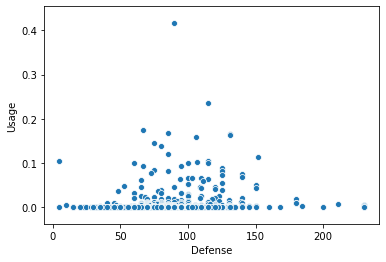

```python
ax1= sns.scatterplot(x= "Defense", y="Usage", data=pokemon_usage_dataframe_1695)
```

Here is Defense vs Usage for players with an Elo above 1825.

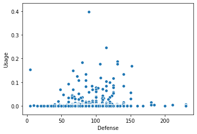

```python
ax1= sns.scatterplot(x= "Defense", y="Usage", data=pokemon_usage_dataframe_1825)
```

From the scatter plots above it is visible that Pokemon with defenses between 50 and 130 tend to be used more than those with higher and lower defense.

#### Special Attack vs Usage

Now let's generate scatter plots based off of Special Attack vs Usage for each tier of competitive Pokemon.

Here is Special Attack vs Usage for players with an Elo between 0 and 1500.

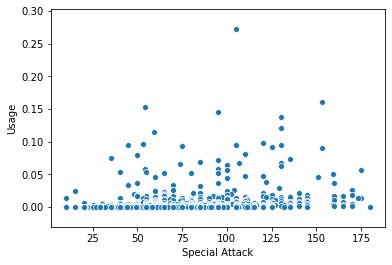

```python
ax1= sns.scatterplot(x= "Special Attack", y="Usage", data=pokemon_usage_dataframe_0)
```

Here is Special Attack vs Usage for players with an Elo between 1500 and 1695.

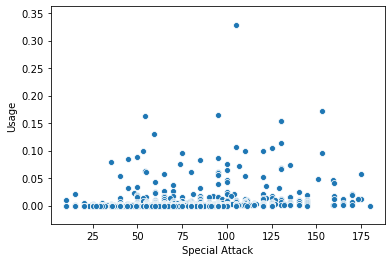

```python
ax1= sns.scatterplot(x= "Special Attack", y="Usage", data=pokemon_usage_dataframe_1500)
```

Here is Special Attack vs Usage for players with an Elo between 1695 and 1825.

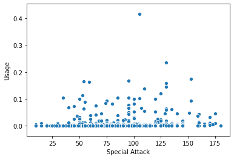

```python
ax1= sns.scatterplot(x= "Special Attack", y="Usage", data=pokemon_usage_dataframe_1695)
```

Here is Special Attack vs Usage for players with an Elo above 1825.

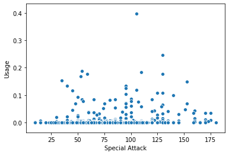

```python
ax1= sns.scatterplot(x= "Special Attack", y="Usage", data=pokemon_usage_dataframe_1825)
```

There does not seem to be a very clear relationship between Special Attack and Usage as there is a much bigger spread in the points the scatter plots. However, when disregarding outliers a somewhat linear trend is visible.

#### Special Defense vs Usage

Now let's generate scatter plots based off of Special Defense vs Usage for each tier of competitive Pokemon.

Here is Special Defense vs Usage for players with an Elo between 0 and 1500.

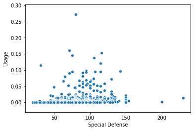

```python
ax1= sns.scatterplot(x= "Special Defense", y="Usage", data=pokemon_usage_dataframe_0)
```

Here is Special Defense vs Usage for players with an Elo between 1500 and 1695.

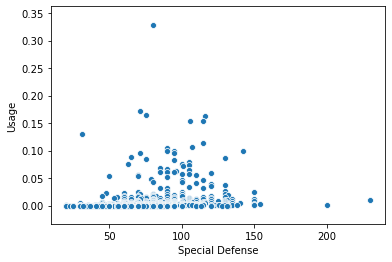

```python
ax1= sns.scatterplot(x= "Special Defense", y="Usage", data=pokemon_usage_dataframe_1500)
```

Here is Special Defense vs Usage for players with an Elo between 1695 and 1825.

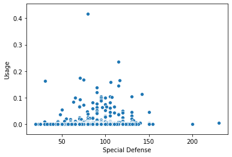

```python
ax1= sns.scatterplot(x= "Special Defense", y="Usage", data=pokemon_usage_dataframe_1695)
```

Here is Special Defense vs Usage for players with an Elo above 1825

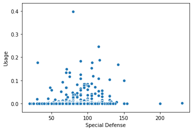

```python
ax1= sns.scatterplot(x= "Special Defense", y="Usage", data=pokemon_usage_dataframe_1825)
```

From the plots above it is can be seen that Pokemon with Special Defense between 80 and 120 tend to have higher usage than other Pokemon.

#### Speed vs Usage

Now let's generate scatter plots based off of Speed vs Usage for each tier of competitive Pokemon.

Here is Speed vs Usage for players with an Elo between 0 and 1500.

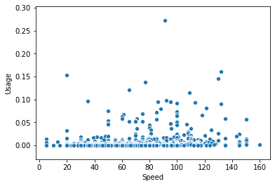

```python
ax1= sns.scatterplot(x= "Speed", y="Usage", data=pokemon_usage_dataframe_0)
```

Here is Speed vs Usage for players with an Elo between 1500 and 1695.

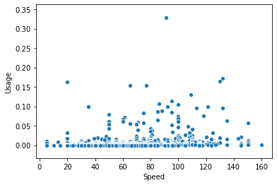

```python
ax1= sns.scatterplot(x= "Speed", y="Usage", data=pokemon_usage_dataframe_1500)
```

Here is Speed vs Usage for players with an Elo between 1695 and 1825.

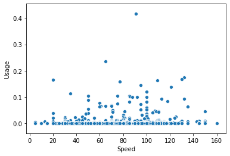

```python
ax1= sns.scatterplot(x= "Speed", y="Usage", data=pokemon_usage_dataframe_1695)
```

Here is Speed vs Usage for players with an Elo above 1825.

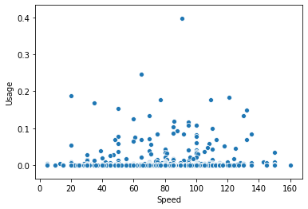

```python
ax1= sns.scatterplot(x= "Speed", y="Usage", data=pokemon_usage_dataframe_1825)
```

Outside of the outlier values in the plots a somewhat linear trend can be observed in the scatter plots for Speed vs Usage.

The scatter plots created for each stat vs usage did show some trend between them and usage, but they were still unclear. This is the reason why I grouped the stats together earlier in the tidying data part of this tutorial. Now I will make scatter plots for Attack and Speed, Special Attack and Speed, Attack + Special Attack, Defense + Special Defense, and stat total.

#### Attack + Speed vs Usage

Now let's generate scatter plots based off of Attack + Speed vs Usage for each tier of competitive Pokemon.

Here is Attack + Speed vs Usage for players with an Elo between 0 and 1500.

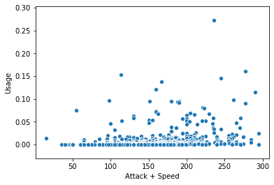

```python
ax1= sns.scatterplot(x= "Attack + Speed", y="Usage", data=pokemon_usage_dataframe_0)
```

Here is Attack + Speed vs Usage for players with an Elo between 1500 and 1695.

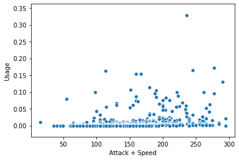

```python
ax1= sns.scatterplot(x= "Attack + Speed", y="Usage", data=pokemon_usage_dataframe_1500)
```

Here is Attack + Speed vs Usage for players with an Elo between 1695 and 1825.

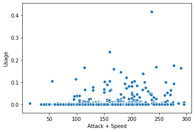

```python
ax1= sns.scatterplot(x= "Attack + Speed", y="Usage", data=pokemon_usage_dataframe_1695)
```

Here is Attack + Speed vs Usage for players with an Elo above 1825.

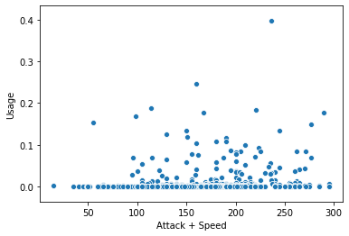

```python
ax1= sns.scatterplot(x= "Attack + Speed", y="Usage", data=pokemon_usage_dataframe_1825)
```

There is much better trend visible from Attack + Speed vs Usage. From the scatter plots it can be seen that Pokemon with higher Attack + Speed totals tend to be used more than Pokemon with lower Attack + Speed totals.

Now let's generate scatter plots based off of Special Attack + Speed vs Usage for each tier of competitive Pokemon.

Here is Special Attack + Speed vs Usage for players with an Elo between 0 and 1500.

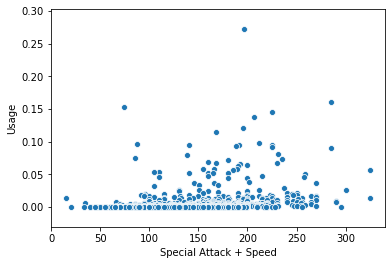

```python
ax1= sns.scatterplot(x= "Special Attack + Speed", y="Usage", data=pokemon_usage_dataframe_0)
```

Here is Special Attack + Speed vs Usage for players with an Elo between 1500 and 1695.

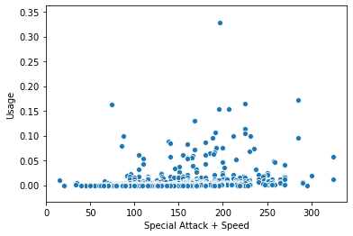

```python
ax1= sns.scatterplot(x= "Special Attack + Speed", y="Usage", data=pokemon_usage_dataframe_1500)
```

Here is Special Attack + Speed vs Usage for players with an Elo between 1695 and 1825.

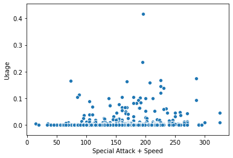

```python
ax1= sns.scatterplot(x= "Special Attack + Speed", y="Usage", data=pokemon_usage_dataframe_1695)
```

Here is Special Attack + Speed vs Usage for players with an Elo 1825 and above.

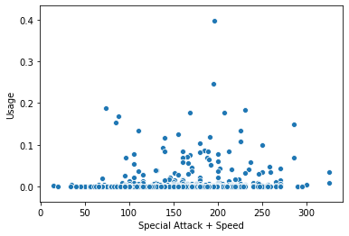

```python
ax1= sns.scatterplot(x= "Special Attack + Speed", y="Usage", data=pokemon_usage_dataframe_1825)
```

Once again, a linear trend can be seen with Special Attack + Speed vs Usage can be seen from the scatter plots. The trend between Attack and Speed was more apparent, but there is a linear trend between Special Attack and Speed.

#### Attack + Special Attack vs Usage

Now let's generate scatter plots based off of Attack + Special Attack vs Usage for each tier of competitive Pokemon.

Here is Attack + Special Attack vs Usage for players with an Elo between 0 and 1500.

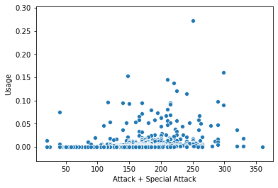

```python
ax1= sns.scatterplot(x= "Attack + Special Attack", y="Usage", data=pokemon_usage_dataframe_0)
```

Here is Attack + Special Attack vs Usage for players with an Elo between 1500 and 1695.

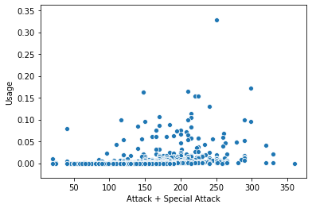

```python
ax1= sns.scatterplot(x= "Attack + Special Attack", y="Usage", data=pokemon_usage_dataframe_1500)
```

Here is Attack + Special Attack vs Usage for players with an Elo between 1695 and 1825.

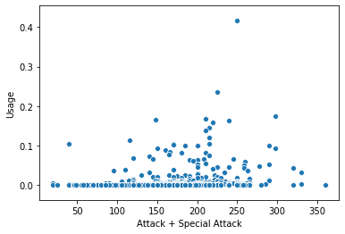

```python
ax1= sns.scatterplot(x= "Attack + Special Attack", y="Usage", data=pokemon_usage_dataframe_1695)
```

Here is Attack + Special Attack vs Usage for players with an Elo above 1825.

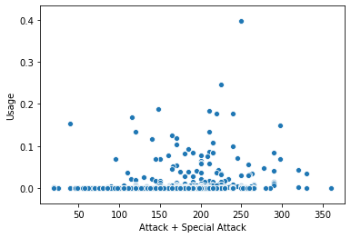

```python
ax1= sns.scatterplot(x= "Attack + Special Attack", y="Usage", data=pokemon_usage_dataframe_1825)
```

There is once again a linear trend visible between Attack + Special Attack and Usage. However, the trend is less apparent for higher tier play than it is for lower tier play. This could indicate that less experienced players tend to pick Pokemon in a less optimal way than more skilled players by choosing Pokemon with higher stat totals rather than considering other factors. This hypothesis will not be tested in this tutorial, but it is an interesting topic for a future tutorial.